# Random Forest Prediction

Maximilian Weissenbacher

16 7 2021

```r
knitr::opts_chunk$set(cache = T)
```

# Car Price Prediction with the Random Forest Algorithm

We saw, that the requirements for the linear regression wasn’t satisfied. In this sheet, it will be tried if you can predict the price of a car with the Random Forest Algorithm.

```r
set.seed(123)
cars <- read.csv("cars_no_outliers.csv")
cars <- cars[complete.cases(cars), ]
str(cars)
```

```
## 'data.frame':    31360 obs. of  22 variables:
##  $ X             : int  1 2 3 4 5 6 7 8 9 10 ...
##  $ name          : chr  "Opel Corsa" "Audi A3" "Opel Astra" "BMW 320" ...
##  $ marke         : chr  "Opel" "Audi" "Opel" "BMW" ...
##  $ modell        : chr  "Corsa" "A3" "Astra" "320" ...
##  $ preis         : num  299 950 2490 3500 4000 ...
##  $ karosserie    : chr  "Limousine" "Limousine" "Coupé" "Coupé" ...
##  $ zustand       : chr  "Gebraucht" "Gebraucht" "Gebraucht" "Gebraucht" ...
##  $ zulassung     : int  2000 2000 2000 2000 2000 2000 2000 2000 2000 2000 ...
##  $ farbe         : chr  "Blau" "Silber" "Gelb" "Silber" ...
##  $ tueren        : int  2 5 2 2 2 2 4 2 3 3 ...
##  $ hubraum       : int  1199 1595 2198 1991 1998 1998 2979 3996 1595 1985 ...
##  $ sitzplätze    : int  5 5 4 5 2 2 5 4 5 5 ...
##  $ fahrzeughalter: num  3 3 2 2 2 3 2 1 3 1 ...
##  $ getriebe      : chr  "Schaltgetriebe" "Schaltgetriebe" "Schaltgetriebe" "Automatik" ...
##  $ ps            : int  65 101 147 150 193 136 231 284 101 150 ...
##  $ km            : num  126000 230800 178269 213000 200000 ...
##  $ kraftstoff    : chr  "Benzin" "Benzin" "Benzin" "Benzin" ...
##  $ co2           : num  151 187 209 212 228 217 230 287 178 201 ...
##  $ verbrauch     : num  6.3 7.8 8.7 8.9 9.5 9.1 9.6 12.1 7.4 8.5 ...
##  $ baujahr       : chr  "01/2000" "05/2000" "09/2000" "02/2000" ...
##  $ descri        : chr  "" "" "" "" ...
##  $ Alter         : int  21 21 21 21 21 21 21 21 21 21 ...
```

## Create Train/Test Data

```r
#Convert characters to factors
cars[sapply(cars, is.character)] <- lapply(cars[sapply(cars, is.character)],
                                                       as.factor)
car <- cars
car$descri <- NULL
car$zulassung <- NULL
car$name <- NULL
car$X <- NULL
car$baujahr <- NULL
str(car)
```

```
## 'data.frame':    30845 obs. of  17 variables:
##  $ marke         : Factor w/ 54 levels "Abarth","Alfa Romeo",..: 40 7 35 35 7 24 35 53 53 53 ...
##  $ modell        : Factor w/ 761 levels "1007","107","108",..: 135 39 613 613 43 747 171 510 156 379 ...
##  $ preis         : num  2490 3500 4000 4444 11490 ...
##  $ karosserie    : Factor w/ 7 levels "Cabrio","Coupé",..: 2 2 1 1 5 1 4 5 5 1 ...
##  $ zustand       : Factor w/ 2 levels "Gebraucht","Jahreswagen": 1 1 1 1 1 1 1 1 1 1 ...
##  $ farbe         : Factor w/ 15 levels "Beige","Blau",..: 5 13 12 13 13 9 13 7 12 11 ...
##  $ tueren        : int  2 2 2 2 4 2 4 5 2 2 ...
##  $ hubraum       : int  2198 1991 1998 1998 2979 3996 1998 1896 1984 1781 ...
##  $ sitzplätze    : int  4 5 2 2 5 4 5 5 4 4 ...
##  $ fahrzeughalter: num  2 2 2 3 2 1 3 2 3 3 ...
##  $ getriebe      : Factor w/ 5 levels "- (Getriebeart)",..: 5 3 3 5 3 3 3 5 5 5 ...
##  $ ps            : int  147 150 193 136 231 284 136 131 116 75 ...
##  $ km            : num  178269 213000 200000 187195 75000 ...
##  $ kraftstoff    : Factor w/ 6 levels "Autogas (LPG)",..: 2 2 2 2 2 2 2 3 2 2 ...
##  $ co2           : num  209 212 228 217 230 287 222 157 211 185 ...
##  $ verbrauch     : num  8.7 8.9 9.5 9.1 9.6 12.1 9.4 5.8 8.8 7.7 ...
##  $ Alter         : int  21 21 21 21 21 21 21 21 21 21 ...
```

```r
# these rows are removed because they are not too useful for the prediction.
# "zulassung" and "baujahr" represented the same and they got replaced by "Alter".

# Create train and test dataset
train.index <- createDataPartition(car$preis, list = FALSE, p = 0.75)
train <- car[train.index, ]
test <- car[-train.index, ]
```

## Create first model (purpose is to try out if everything works)

Now let’s create the Random Forest Model. As first approach I want to predict the price of the car with the variable “ps” and “km”. Later on there will be a model with every variable in the model.

```r
train1 <- train
test1 <- test
set.seed(123)
rf_model <- randomForest(preis ~ ps + km, data = train1)
print(rf_model)
```

```
##
## Call:
##  randomForest(formula = preis ~ ps + km, data = train1)
##                Type of random forest: regression
##                      Number of trees: 500
## No. of variables tried at each split: 1
##
##           Mean of squared residuals: 84967837
##                     % Var explained: 80.94
```

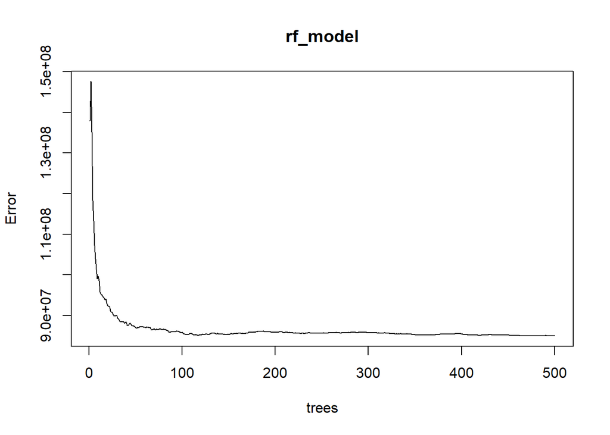

```r
pred <- predict(rf_model, test1)
plot(rf_model)
```

When plotting the model, it can be seen that the error rate decreases if the number of trees increases. At the first look, it looks like that the default value of 500 trees is enough for this model.

In the next step, the model predicts the price of the test data set. The R2-value also gets computed:

```r
test1$preis_pred <- predict(rf_model, test1)
evalu <- data.frame(test1$marke, test1$preis, test1$preis_pred)
evalu[1:30,]
```

```
##      test1.marke test1.preis test1.preis_pred
## 1  Mercedes-Benz        4444         7175.137
## 2         Jaguar       19900        21461.030
## 3     Volkswagen        1500         3550.136
## 4     Volkswagen        1995         2918.958
## 5  Mercedes-Benz        2799         7124.958
## 6           Ford        3950         6657.933
## 7  Mercedes-Benz        5199        11739.100
## 8  Mercedes-Benz        5790         8779.616
## 9           Opel        1350         3071.674
## 10         Skoda        1999         3911.269
## 11        Suzuki        2490         3134.343
## 12          Saab        2750         7900.473
## 13 Mercedes-Benz        3990        14322.485
## 14    Volkswagen        4650         7752.971
```

[output cut: 16 more lines]

```r
print(rSquared(test1$preis, test1$preis - test1$preis_pred))
```

```
##           [,1]
## [1,] 0.8170662
```

The R2 value is quite high with 82%. But in the next step, I want to check if I can increase the value if I include more variables in the model. The Random Forest Function can not handle categorical predictors with more than 53 categories. This is the case with all car makes. To solve this problem, I just use the car makes which are most present in the data set (can be seen in the Data Cleaning Sheet).

## Create model with every variable for the price prediction

First convert categorical variables to factors:

```r
train$getriebe <- as.factor(train$getriebe)
train$kraftstoff <- as.factor(train$kraftstoff)
train$marke <- as.factor(train$marke)
train$modell <- as.factor(train$modell)
train$farbe <- as.factor(train$farbe)
train$zustand <- as.factor(train$zustand)
train$kraftstoff <- as.numeric(train$kraftstoff)
train$getriebe <- as.numeric(train$getriebe)
train$marke <- as.numeric(train$marke)
train$modell <- as.numeric(train$modell)
train$farbe <- as.numeric(train$farbe)
train$zustand <- as.numeric(train$zustand)
train$karosserie <- as.factor(train$karosserie)
train$karosserie <- as.numeric(train$karosserie)
test$karosserie <- as.factor(test$karosserie)
test$getriebe <- as.factor(test$getriebe)
test$kraftstoff <- as.factor(test$kraftstoff)
test$marke <- as.factor(test$marke)
test$modell <- as.factor(test$modell)
test$farbe <- as.factor(test$farbe)
test$zustand <- as.factor(test$zustand)
test$kraftstoff <- as.numeric(test$kraftstoff)
test$getriebe <- as.numeric(test$getriebe)
test$marke <- as.numeric(test$marke)
test$modell <- as.numeric(test$modell)
test$farbe <- as.numeric(test$farbe)
test$zustand <- as.numeric(test$zustand)
test$karosserie <- as.numeric(test$karosserie)
train <- train[complete.cases(train), ]
```

```r
# this loop has to be done because the test set has not included all levels and as a reason
# of this the predict function throwed some errors. This kind of error seems to be a bug of the
# randomForest package because many people are facing this problem.
common <- intersect(names(train), names(test))
for (p in common) {
  if (class(train[[p]]) == "factor") {
    levels(test[[p]]) <- levels(train[[p]])
  }
}
test <- rbind(train[1, ] , test)
test <- test[-1,]

set.seed(123)
rf_model1 <- randomForest(preis ~ ., data = train, localImp=TRUE)
#save(rf_model1, file = "rf_model1.rda")
#load("rf_model1.rda")
print(rf_model1)
```

```
##
## Call:
##  randomForest(formula = preis ~ ., data = train, localImp = TRUE)
##                Type of random forest: regression
##                      Number of trees: 500
## No. of variables tried at each split: 5
##
##           Mean of squared residuals: 34032857
##                     % Var explained: 92.36
```

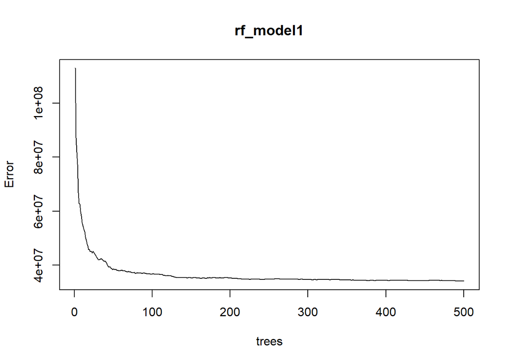

```r
plot(rf_model1)
```

```r
test$preis_pred_rf_model1 <- predict(rf_model1, test)
evalu1 <- data.frame(test$marke, test$preis, test$preis_pred_rf_model1)
```

Look at some predictions:

```r
evalu1[1:30,]
```

```
##    test.marke test.preis test.preis_pred_rf_model1
## 1          35       4444                  5772.243
## 2          24      19900                 26145.468
## 3          53       1500                  3622.514
## 4          53       1995                  3302.806
## 5          35       2799                  5147.516
## 6          19       3950                 19819.359
## 7          35       5199                  7018.227
## 8          35       5790                  5695.923
## 9          40       1350                  2021.803
## 10         47       1999                  2471.230
## 11         51       2490                  2011.063
## 12         45       2750                  4021.969
## 13         35       3990                  6276.961
## 14         53       4650                  5771.940
```

[output cut: 16 more lines]

```r
print(rSquared(test$preis, test$preis - test$preis_pred_rf_model1))
```

```
##           [,1]
## [1,] 0.9187842
```

Now the R-Squared value is very high with 0.9. So this model seems to be a good one.

```r
# check which variables are important
# importance_frame <- measure_importance(rf_model1)
#save(importance_frame, file = "importance_frame.rda")
load("importance_frame.rda")
importance_frame
```

```
##          variable mean_min_depth no_of_nodes mse_increase node_purity_increase
## 1           Alter          2.132      288375  132442252.1         9.942748e+11
## 2             co2          4.122      424463   10662245.6         1.490077e+11
## 3  fahrzeughalter          4.622      166524    2723789.8         6.471175e+10
## 4           farbe          5.612      347261    1422329.0         4.939595e+10
## 5        getriebe          2.856       33646   42972751.0         4.425367e+11
## 6         hubraum          2.282      206496  102404471.6         1.052318e+12
## 7      karosserie          3.500      200170   17102270.6         2.239980e+11
## 8              km          1.982      643532  107815966.4         1.162697e+12
## 9      kraftstoff          5.728       43142    2509669.2         2.135825e+10
## 10          marke          1.992      250630   96880087.8         1.234697e+12
## 11         modell          3.412      310700   26628507.2         2.696757e+11
## 12             ps          1.150      266627  235575580.2         3.094019e+12
## 13     sitzplätze          4.254       63121    9460479.1         8.976912e+10
## 14         tueren          4.170      189716   16843929.7         1.503981e+11
```

[output cut: 19 more lines]

```r
importance(rf_model1)
```

```
##                  %IncMSE IncNodePurity
## marke          34.698682  2.274718e+11
## modell         32.758909  2.670601e+11
## karosserie     18.973241  3.217869e+11
## zustand        10.546641  2.061220e+10
## farbe           3.458928  5.211056e+10
## tueren         15.301990  1.881233e+11
## hubraum        14.045469  1.548165e+12
## sitzplätze     18.828905  1.806755e+11
## fahrzeughalter 10.915828  8.006695e+10
## getriebe       12.257891  5.072711e+11
## ps             28.361509  3.435559e+12
## km             37.047777  1.261474e+12
## kraftstoff      9.767107  2.855588e+10
## co2            21.186086  1.708026e+11
## verbrauch      12.918731  8.439956e+11
## Alter          40.569983  1.020651e+12
```

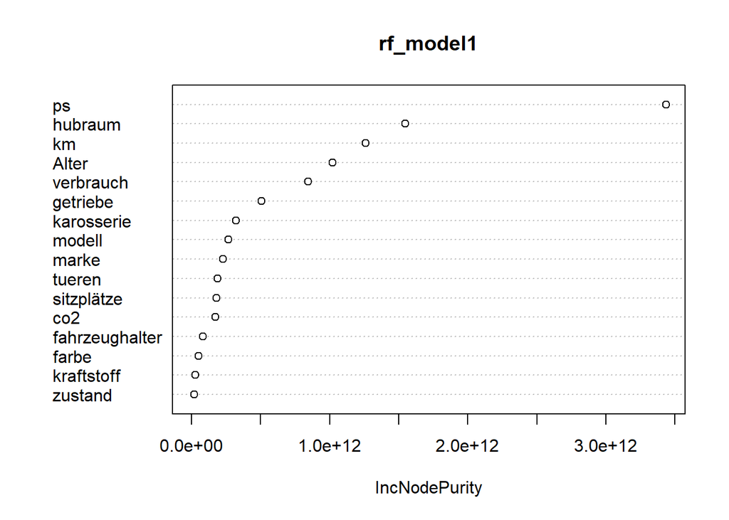

```r
#plot:
varImpPlot(rf_model1,type=2)
```

```r
# Model with important variables:
set.seed(123)
rf_model2 <- randomForest(preis ~ ps+km+marke+hubraum+Alter, data = train, localImp=TRUE)
print(rf_model2)
```

```
##
## Call:
##  randomForest(formula = preis ~ ps + km + marke + hubraum + Alter,      data = train, localImp = TRUE)
##                Type of random forest: regression
##                      Number of trees: 500
## No. of variables tried at each split: 1
##
##           Mean of squared residuals: 46595671
##                     % Var explained: 89.54
```

```r
test$preis_pred_rf_model2 <- predict(rf_model2, test)
evalu2 <- data.frame(test$marke, test$preis, test$preis_pred_rf_model2)
evalu2[1:30, ]
```

```
##    test.marke test.preis test.preis_pred_rf_model2
## 1          35       4444                  3390.106
## 2          24      19900                 24073.554
## 3          53       1500                  3070.563
## 4          53       1995                  2139.740
## 5          35       2799                  4383.747
## 6          19       3950                 10998.833
## 7          35       5199                  8899.315
## 8          35       5790                  5730.085
## 9          40       1350                  1950.790
## 10         47       1999                  2768.030
## 11         51       2490                  2289.654
## 12         45       2750                  5200.526
## 13         35       3990                  7232.694
## 14         53       4650                  5900.342
```

[output cut: 16 more lines]

```r
print(rSquared(test$preis, test$preis - test$preis_pred_rf_model2))
```

```
##           [,1]
## [1,] 0.8869028
```

The R2 of the model is lower again (makes sense because the model uses less variables). But you can see that these variables provide a high r squarded value.

## Next model: Find optimal mtry value

The number of variables selected at each split is denoted by mtry in randomforest function. In this step I want to find out the optimal mtry value and the build a model again based on the results to see if I can boost the model performance.I want to get the mtry value where out of bag error is at its minimum.The model before, the number of variables selected at each split was 5.

```r
#saved "mtry" because it takes very long to compute
#mtry <- tuneRF(train[-1],train$preis, ntreeTry=500,stepFactor=1.5,improve=0.01, trace=TRUE, plot=TRUE)
load("mtry.rda")
best.m <- mtry[mtry[, 2] == min(mtry[, 2]), 1]
print(mtry)
```

```
##    mtry  OOBError
## 4     4 6770175.7
## 5     5 4834612.6
## 7     7 2707684.2
## 10   10 1151827.7
## 15   15  535275.5
## 16   16  494223.2
```

```r
print(best.m)
```

```
## [1] 16
```

Now you can see that the best mtry value is at 16 and not at 5 anymore. So lets build a model with this information:

```r
set.seed(47)
rf_mtry <-randomForest(preis~.,data=train, mtry=best.m, importance=TRUE,ntree=500)
print(rf_mtry)
```

```
##
## Call:
##  randomForest(formula = preis ~ ., data = train, mtry = best.m,      importance = TRUE, ntree = 500)
##                Type of random forest: regression
##                      Number of trees: 500
## No. of variables tried at each split: 16
##
##           Mean of squared residuals: 36465626
##                     % Var explained: 91.82
```

```r
#Evaluate variable importance
importance(rf_mtry)
```

```
##                    %IncMSE IncNodePurity
## marke           53.0525232  2.131957e+11
## modell          36.1636397  2.068571e+11
## karosserie      16.7263654  5.327205e+10
## zustand          4.9294416  3.583008e+09
## farbe            0.8106926  3.569688e+10
## tueren          34.1124726  2.360283e+11
## hubraum         17.6725329  1.508028e+11
## sitzplätze      14.1587121  5.906897e+10
## fahrzeughalter  11.9801411  1.368415e+10
## getriebe        11.7912236  3.157094e+10
## ps             172.4825488  6.351462e+12
## km              53.9951010  1.304242e+12
## kraftstoff      23.3199230  1.235082e+10
## co2             19.0335352  1.050555e+11
## verbrauch       19.3841608  3.820070e+11
## Alter           48.0612391  1.051419e+12
```

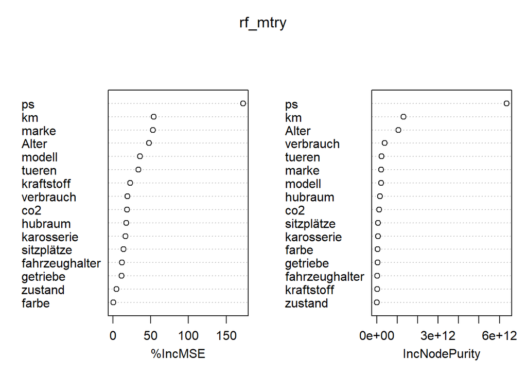

```r
varImpPlot(rf_mtry)
```

```r
test$preis_pred_rf_mtry <- predict(rf_mtry, test)
print(rSquared(test$preis, test$preis - test$preis_pred_rf_mtry))
```

```
##           [,1]
## [1,] 0.9168394
```

## Model without correlation

In the data cleaning sheet we saw that “ps” and “hubraum” got a high correlation (0.89). So now make a model without “hubraum” to see how the model performance changes and how the variable importance changes.

```r
set.seed(123)
#rf_model3 <- randomForest(preis ~ ps+km+marke+Alter+verbrauch+zustand+kraftstoff+farbe+fahrzeughalter+getriebe+sitzplätze+tueren+modell+karosserie+co2, data = train, localImp=TRUE)
#save(rf_model3, file = "rf_model3.rda")
load("rf_model3.rda")
print(rf_model3)
```

```
##
## Call:
##  randomForest(formula = preis ~ ps + km + marke + Alter + verbrauch +      zustand + kraftstoff + farbe + fahrzeughalter + getriebe +      sitzplätze + tueren + modell + karosserie + co2, data = train,      localImp = TRUE)
##                Type of random forest: regression
##                      Number of trees: 500
## No. of variables tried at each split: 5
##
##           Mean of squared residuals: 32782739
##                     % Var explained: 92.73
```

```r
test$preis_pred_rf_model3 <- predict(rf_model3, test)
evalu3 <- data.frame(test$marke, test$preis, test$preis_pred_rf_model3)
evalu3[1:30, ]
```

```
##    test.marke test.preis test.preis_pred_rf_model3
## 1          35       4444                  5720.998
## 2          24      19900                 22482.132
## 3          53       1500                  2805.886
## 4          53       1995                  2280.896
## 5          35       2799                  4033.595
## 6          19       3950                 10924.340
## 7          35       5199                  6946.462
## 8          35       5790                  5706.519
## 9          40       1350                  1038.225
## 10         47       1999                  1430.104
## 11         51       2490                  1645.112
## 12         45       2750                  2296.394
## 13         35       3990                  5003.094
## 14         53       4650                  5013.674
```

[output cut: 16 more lines]

```r
print(rSquared(test$preis, test$preis - test$preis_pred_rf_model3))
```

```
##          [,1]
## [1,] 0.961942
```

```r
importance(rf_model3)
```

```
##                  %IncMSE IncNodePurity
## ps             57.732586  4.111330e+12
## km             37.475198  1.317711e+12
## marke          30.736428  2.826887e+11
## Alter          36.258436  1.103620e+12
## verbrauch      21.706954  1.382273e+12
## zustand         9.783071  2.131021e+10
## kraftstoff     22.351221  4.292433e+10
## farbe           4.769607  5.335586e+10
## fahrzeughalter 12.101296  8.296225e+10
## getriebe       15.734237  7.067583e+11
## sitzplätze     18.311810  2.008364e+11
## tueren          8.841174  1.733519e+11
## modell         34.472011  3.518286e+11
## karosserie     13.047200  4.538307e+11
## co2            23.131677  2.243981e+11
```

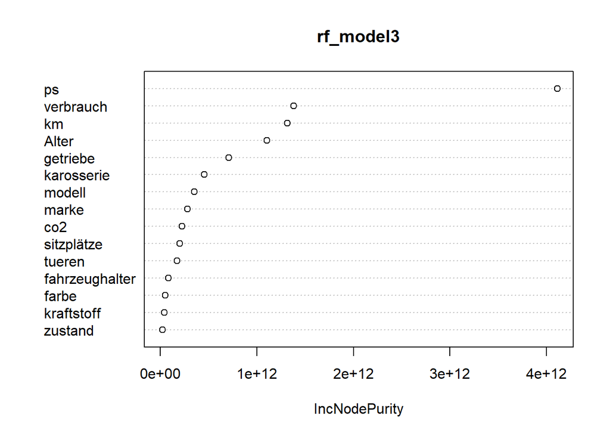

```r
#plot:
varImpPlot(rf_model3,type=2)
```

The R2 is very high now with 0.96. This model is the best one for prediction yet! Here is a plot of the acutal values vs. the predicted values:

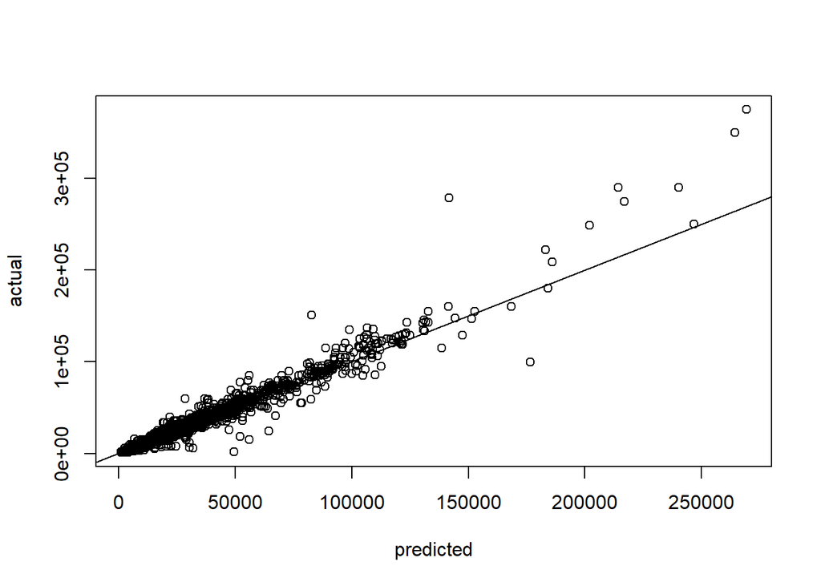

```r
 plot(test$preis_pred_rf_model3,test$preis,
      xlab="predicted",ylab="actual")
 abline(a=0,b=1)
```

In this plot you can see that predictions until about 125000 Euros are quite good. For high priced cars, the accuaracy isn’t that high, probably because there aren’t too many cars that cost for example ~350000 Euros.

## Use Random Forest for classification: Predict car make

Just for trying out, I want to predict the make of a car. If the dependent variable is a factor, then the randomForest function makes a classification instead of a regression.

```r
# Also Random Forest with categorisation: f.e. Marke vorhersagen
x <- cars
x$descri <- NULL
x$modell <- NULL
x$name <- NULL
x$baujahr <- NULL
x$X <- NULL
#Convert Fators to Numeric for lmFuncs
# x$marke <- as.numeric(x$marke)
x$karosserie <- as.numeric(x$karosserie)
x$zustand <- as.numeric(x$zustand)
x$farbe <- as.numeric(x$farbe)
x$getriebe <- as.numeric(x$getriebe)
x$kraftstoff <- as.numeric(x$kraftstoff)
x <- x[complete.cases(x), ]
x <- x %>%
  filter(str_detect(marke,'BMW|Audi|Citroen|Fiat|Ford|Hyundai|Kia|Mercedes-Benz|Nissan|Opel|Peugeot|Porsche|Renault|SEAT|Skoda|smart|Suzuki|Volkswagen|Volvo'))
x$marke <- factor(x$marke)
x.index <- createDataPartition(x$preis, list = FALSE, p = 0.75)
x_train <- x[x.index, ]
x_test <- x[-x.index, ]
str(x)
```

```
## 'data.frame':    30304 obs. of  17 variables:
##  $ marke         : Factor w/ 19 levels "Audi","BMW","Citroen",..: 10 2 8 8 2 8 18 18 18 18 ...
##  $ preis         : num  2490 3500 4000 4444 11490 ...
##  $ karosserie    : num  2 2 1 1 5 4 5 5 1 5 ...
##  $ zustand       : num  1 1 1 1 1 1 1 1 1 1 ...
##  $ zulassung     : int  2000 2000 2000 2000 2000 2000 2000 2000 2000 2000 ...
##  $ farbe         : num  5 13 12 13 13 13 7 12 11 13 ...
##  $ tueren        : int  2 2 2 2 4 4 5 2 2 5 ...
##  $ hubraum       : int  2198 1991 1998 1998 2979 1998 1896 1984 1781 1595 ...
##  $ sitzplätze    : int  4 5 2 2 5 5 5 4 4 5 ...
##  $ fahrzeughalter: num  2 2 2 3 2 3 2 3 3 2 ...
##  $ getriebe      : num  5 3 3 5 3 3 5 5 5 3 ...
##  $ ps            : int  147 150 193 136 231 136 131 116 75 101 ...
##  $ km            : num  178269 213000 200000 187195 75000 ...
##  $ kraftstoff    : num  2 2 2 2 2 2 3 2 2 2 ...
##  $ co2           : num  209 212 228 217 230 222 157 211 185 206 ...
##  $ verbrauch     : num  8.7 8.9 9.5 9.1 9.6 9.4 5.8 8.8 7.7 8.6 ...
##  $ Alter         : int  21 21 21 21 21 21 21 21 21 21 ...
```

```r
set.seed(123)
rf_marke <- randomForest(marke~., data = x_train, localImp=TRUE)
rf_marke
```

```
##
## Call:
##  randomForest(formula = marke ~ ., data = x_train, localImp = TRUE)
##                Type of random forest: classification
##                      Number of trees: 500
## No. of variables tried at each split: 4
##
##         OOB estimate of  error rate: 9.61%
## Confusion matrix:
##               Audi  BMW Citroen Fiat Ford Hyundai Kia Mercedes-Benz Nissan Opel
## Audi          2010   30       0    0    2       0   0            21      0    2
## BMW              9 2484       3    0    2       0   0            14      0    0
## Citroen          1    3     785    8   18       4   0             4      0   31
## Fiat             2    0      10 1034    7       3   0             3      0   18
## Ford             3   12       6    9 1076       5   0            11      0    6
## Hyundai          2    9       2    1   11    1214   3             5      0    8
## Kia              0    1       0    0    2      28  19             4      0    4
## Mercedes-Benz   10   23       0    0    0       0   0          2609      0    4
## Nissan           0    4       1    2    3       3   0             2     17    4
## Opel             8   10       7    4   14       7   0            10      0 1328
## Peugeot          2    2      32    2    4       0   0             5      0   15
## Porsche          1    5       0    0    0       0   0             3      0    0
## Renault          0   25       6    1    3       4   0            20      0   15
## SEAT            72    0       0    0    5       0   0             0      0    5
## Skoda           69    2       0    1    7       0   0             3      0    3
## smart            0    0       0    0    0       0   0             0      0    0
## Suzuki           0    2       1    1    6       6   1             1      3    5
## Volkswagen     155    8       1    1    2       0   0            17      0    6
## Volvo           10    7       4    0    4       1   0             4      0    1
##               Peugeot Porsche Renault SEAT Skoda smart Suzuki Volkswagen Volvo
## Audi                0      23       1   15    32     0      0        149     0
## BMW                 0      16       0    0     0     0      0          2     0
## Citroen            11       0       5    2     0     0      0          8     1
## Fiat                0       0       7    2     0     0      0          8     0
## Ford                0       1       6    6     4     0      0          7     0
## Hyundai             0       0       3    2     1     0      0          6     0
## Kia                 0       0       1    0     0     0      1          2     0
## Mercedes-Benz       0      21      12    0     0     0      0          6     0
## Nissan              1       0      12    3     1     0      3          6     0
## Opel                2       0       5    7     8     0      1         15     0
```

[output cut: 14 more lines]

```
## Ford          0.065972222
## Hyundai       0.041831097
## Kia           0.693548387
## Mercedes-Benz 0.028305400
## Nissan        0.725806452
## Opel          0.068723703
## Peugeot       0.628571429
## Porsche       0.007770008
## Renault       0.071994240
## SEAT          0.177892031
## Skoda         0.232887490
## smart         0.070175439
## Suzuki        0.424657534
## Volkswagen    0.146291209
## Volvo         0.150406504
```

```r
marke_pred <- predict(rf_marke, x_test)
x_test$marke_pred <- marke_pred
CFM = table(x_test$marke, x_test$marke_pred)
CFM_acc <- sum(diag(CFM)/sum(CFM))
CFM_acc
```

```
## [1] 0.9042904
```

```r
# Marke zu 90% vorhergesagt
# look at some predictions:
make <- data.frame(marke=x_test$marke, marke_predict=x_test$marke_pred, preis=x_test$preis)
make[1:30,]
```

```
##            marke marke_predict preis
## 1  Mercedes-Benz Mercedes-Benz  4000
## 2  Mercedes-Benz Mercedes-Benz  4444
## 3     Volkswagen    Volkswagen  1500
## 4     Volkswagen    Volkswagen  1995
## 5  Mercedes-Benz Mercedes-Benz  2799
## 6           Ford Mercedes-Benz  3950
## 7  Mercedes-Benz Mercedes-Benz  5199
## 8  Mercedes-Benz Mercedes-Benz  5790
## 9           Opel          Opel  1350
## 10    Volkswagen    Volkswagen  2490
## 11    Volkswagen    Volkswagen  2990
## 12    Volkswagen    Volkswagen  3890
## 13 Mercedes-Benz Mercedes-Benz  4990
## 14    Volkswagen Mercedes-Benz  4990
```

[output cut: 16 more lines]

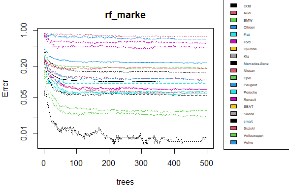

```r
#par(mar = c(5, 4, 3, 8),xpd = TRUE)
#plot(rf_marke, log="y")
#legend("topright",
#       inset = c(- 0.52, -0.25),
#       colnames(rf_marke$err.rate),
#       cex= 0.45,
#       col = 1:20,
#       fill = 1:20
#       )
include_graphics("Rplot.png")
```

Out of this plot you can see that the error rate for BMW or Opel cars is very low (you can see this in the confusion matrix, when printing the model as well). There are bad predictions for Nissan cars, maybe because there aren’t enough data points from this car make. You can think of just using the cars with a low error rate for prediction, so remove for example makes with error rates above 0.5, but this could cause some overfitting problems.

# Conclusion

This project showed some ways for predicting car prices or car makes. At first, the data was scraped from “autoscout24.de”, one of the biggest car selling websites in Germany. During scraping the data, there were some issues. So sometimes the computer loss its internet connection and the scraper got a connection timeout. Sometimes the computer crashed and all of the scraped data in that round got deleted. So overall, the scraping process took a lot of time and one disadvantage of the connection losses was, that there isn’t an equally number of cars for ever make and for every year. But because enough data was scraped anyways, the data was used for further investigation.

As second step, the data was cleaned and visualized, in order to get an understanding of the data. Different plots showed the price distribution, the correlation between variables and other interesting things, like how many kilometers a specific fuel type goes.

The third step was to build models. Initially it was planned to use linear regression to predict the price of a car. Unfortunately it came out, that the requirements for building a linear regression weren’t satisfied. As a reason of this, I looked after machine learning algorithms, that could do this task. As random forests can both, do regression and classification I choose to use this machine learning algorithm for prediction and classification tasks.